# Ilościowe miary ryzyka rynkowego

# Opis danych

Zebrane dane dzienne z okresu 01.01.2006 - 31.12.2021 dotyczą wartości trzech indeksów giełdowych - BUX, BUMIX oraz CETOP i pochodzą z archiwów Giełdy Papierów Wartościowych w Budapeszcie (BSE).

**BUX** składa się z 12 do 25 największych spółek notowanych na BSE. Jest odpowiednikiem indeksów takich jak Dow Jones Industrial Average czy DAX. Indeks BUX jest składnikiem opcji i kontraktów futures notowanych na BSE pod symbolem BUX. Wartość indeksu obliczana jest w czasie rzeczywistym na podstawie kursów rynkowych akcji w koszyku. Oprócz kursów akcji uwzględnia on również prawa poboru i dywidendy. Dzienne zmiany wartości indeksu przedstawia poniższy wykres:

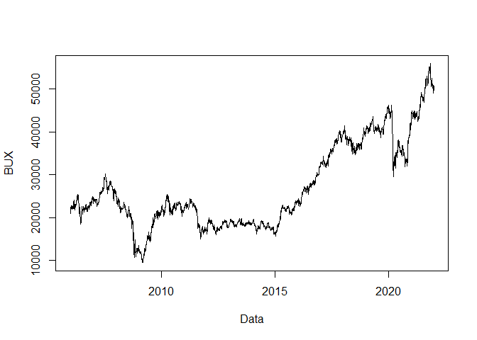

Rozkład gęstości logarytmicznych stóp zwrotu wygląda następująco:

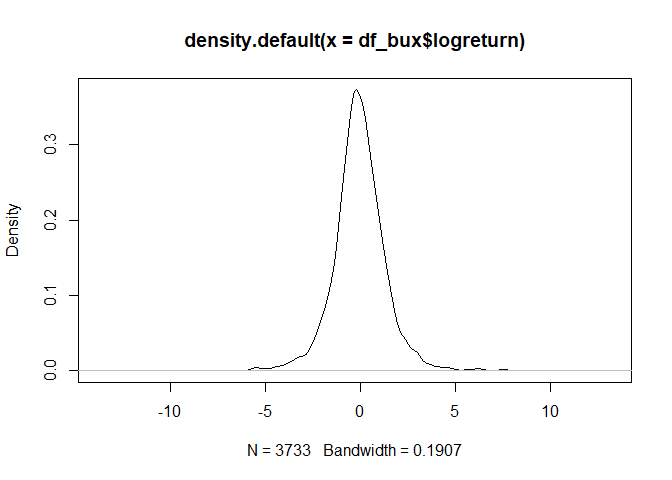

Można zatem stwierdzić, że rozkład ten w przybliżeniu przypomina rozkład normalny.

Przeciętna wartość indeksu odnotowana w badanym okresie wyniosła 2.6886906^{4} z odchyleniem standardowym 9896.0872054. Współczynnik zmienności wynosi 0.3680634 i świadczy o umiarkowanej zmienności odnotowanych wartości indeksu. Zakres odnotowanych wartości to (9461.29 - 5.5925578^{4}). Pierwszy kwantyl wynosi 1.902226^{4}, mediana - 2.3068679^{4} , a trzeci kwartyl - 3.5391467^{4}.

**BUMIX** składa się z 12 do 25 średniej wielkości spółek notowanych na BSE. Spółki uwzględniane w indeksie BUMIX nie mogą przekroczyć kwoty kapitalizacji 125 miliardów forintów. Podobnie jak BUX, BUMIX jest indeksem dochodowym. W badanym okresie wartość indeksu prezentowała się następująco:

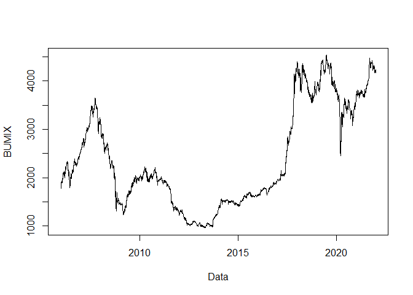

Rozkład gęstości logarytmicznych stóp zwrotu wygląda następująco:

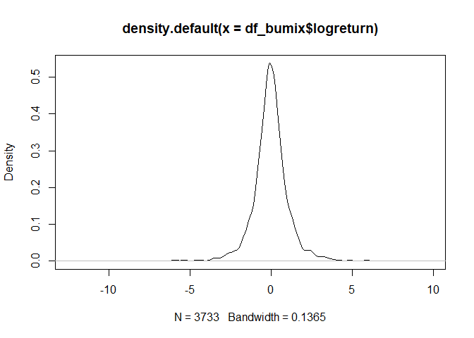

Można zatem stwierdzić, że rozkład ten w przybliżeniu przypomina rozkład normalny.

Przeciętna wartość indeksu odnotowana w badanym okresie wyniosła 2382.4087858 z odchyleniem standardowym 1036.7353801. Współczynnik zmienności wynosi 0.4351627 i świadczy o umiarkowanie wysokiej zmienności odnotowanych wartości indeksu. Zakres odnotowanych wartości to (958.82 - 4532.787473). Pierwszy kwantyl wynosi 1536.40667, mediana - 2011.485 , a trzeci kwartyl - 3397.425.

**CETOP** (Central European Blue Chip Index) odzwierciedla status spółek o największej wartości rynkowej i obrotach w regionie Europy Środkowej. W jego skład wchodzą notowania m.in. KGHM, PZU czy PKN Orlen. W badanym okresie odnotowano następujące wartości indeksu:

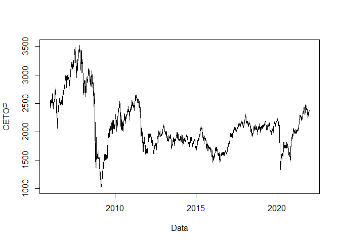

Rozkład gęstości logarytmicznych stóp zwrotu wygląda następująco:

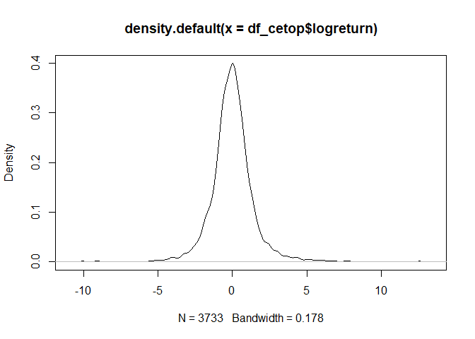

Można zatem stwierdzić, że rozkład ten w przybliżeniu przypomina rozkład normalny, aczkolwiek wydaje się odbiegać od niego nieco silniej niż dwa powyższe.

Przeciętna wartość indeksu odnotowana w badanym okresie wyniosła 2107.5652119 z odchyleniem standardowym 441.841063. Współczynnik zmienności wynosi 0.2096453 i świadczy o przeciętnej zmienności odnotowanych wartości indeksu. Zakres odnotowanych wartości to (1018.22 - 3517.5). Pierwszy kwantyl wynosi 1808.5974275, mediana - 2032.1206125 , a trzeci kwartyl - 2317.5313955.

## ———————————————————————————————

# Wyznaczanie 95% i 99% VaR i ES

W celu wyznaczenia 95% i 99% VaR i ES dla badanych indeksów użyto metod: historycznej, EWMA oraz symulacji Monte Carlo.

## Metoda historyczna

- indeks BUX

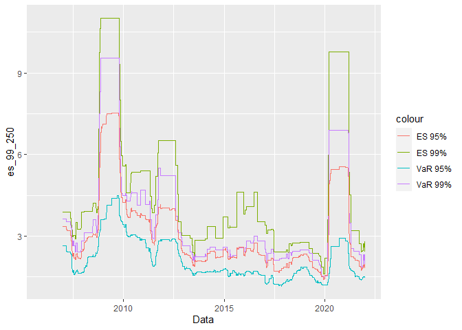

- indeks BUMIX

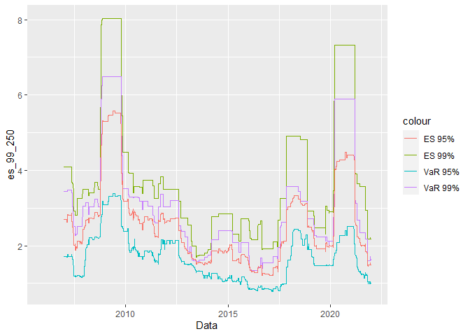

- indeks CETOP

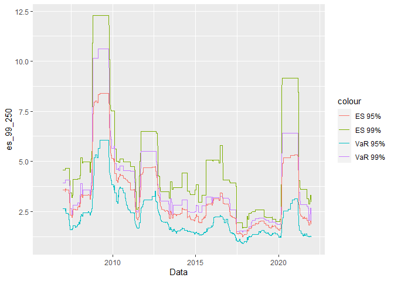

## Metoda zmiennej zmienności w czasie (EWMA)

- indeks BUX

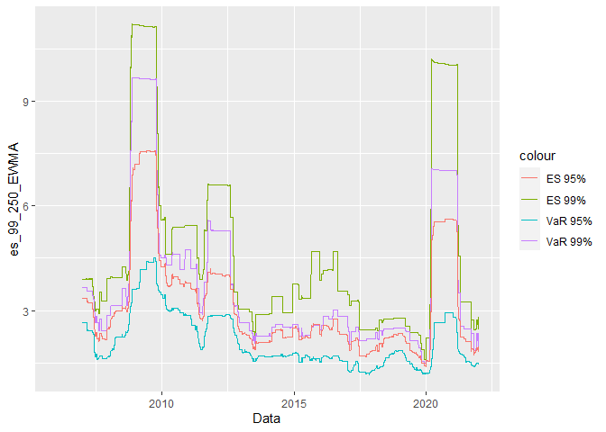

- indeks BUMIX

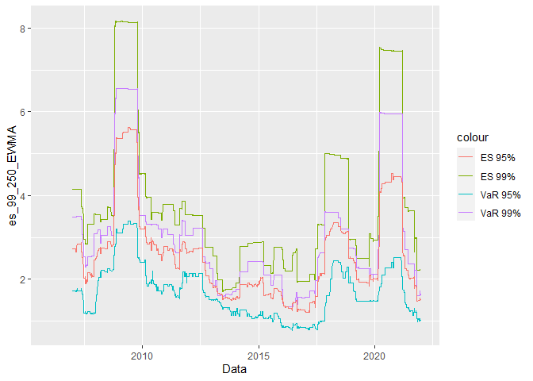

- indeks CETOP

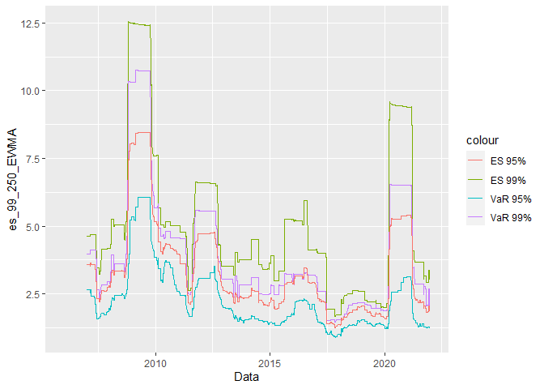

## Metoda symulacji Monte Carlo (liczba symulacji: 1000)

- indeks BUX

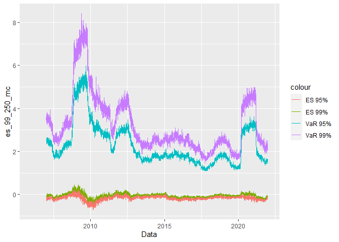

- indeks BUMIX

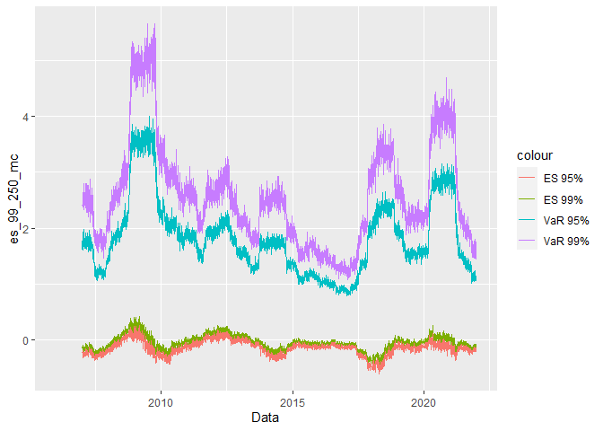

- indeks CETOP

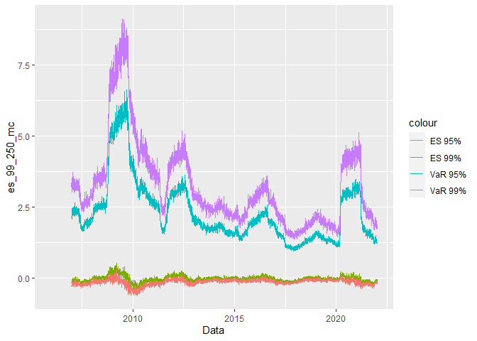

## ———————————————————————————————

# Testy wsteczne

Dla obliczonych wartości 99% VaR użyto testów: Kupca oraz Christoffersona. Wyniki testów przedstawia poniższa tabela:

| indeks | metoda | test Kupca | p | test Christoffersona | p |
| --- | --- | --- | --- | --- | --- |
| BUX | historyczna | 1.4979555 | 0.2209862 | 24.8690098 | 6.1360951^{-7} |
| BUX | EWMA | 1.4979555 | 0.2209862 | 24.8690098 | 6.1360951^{-7} |
| BUX | Monte Carlo | 9.901949 | 0.001651 | 17.8576198 | 2.380641^{-5} |
| BUMIX | historyczna | 9.0265093 | 0.0026609 | 33.7281038 | 6.3378413^{-9} |
| BUMIX | EWMA | 9.0265093 | 0.0026609 | 33.7281038 | 6.3378413^{-9} |
| BUMIX | Monte Carlo | 28.3166485 | 1.0300626^{-7} | 53.6952842 | 2.3414604^{-13} |
| CETOP | historyczna | 3.88014 | 0.0488605 | 1.8315221 | 0.1759479 |
| CETOP | EWMA | 3.1894035 | 0.0741171 | 5.9439192 | 0.0147681 |
| CETOP | Monte Carlo | 5.1966968 | 0.0226299 | 7.545968 | 0.0060145 |

Na podstawie metody symulacji Monte Carlo można stwierdzić, że w okresie od 01.01.2006 do 31.12.2021 przeciętna wartość narażona na ryzyko dla 99% poziomu pewności dla indeksu BUX wynosiła 3.227879, a przeciętna strata po przekroczeniu tej wartości wynosiła -0.0572927. Dla indeksu BUMIX było to odpowiednio 2.5734515 i -0.0454222. Dla indeksu CETOP było to odpowiednio 3.2411452 i -0.0335424.